# Higher Education Students Performance Evaluation

Prepared by: [Hoh Shen Yien](https://shenyien.cyou/about)

[Source code](https://github.com/HohShenYien/data-analysis/blob/main/R%20mark%20down/higher_education_performance.Rmd)

This is a classification analysis to try determining the grade of a student based on other attributes.

Dataset source: https://www.kaggle.com/csafrit2/higher-education-students-performance-evaluation

## Loading Libraries

```r
library(dplyr) # data preprocessing
library(ggplot2) # data visualization
library(e1071) # svm
library(randomForest) # random forest
library(nnet) # multinomial logistic regression
library(glmnet) # the lasso
library(class) # KNN
library(caret) # CV
library(ggdark)
```

## Reading the data and viewing the first few rows

```r
data <- read.csv("./data/student_prediction.csv")
head(data)
```

|  | ï..STUDENTID | AGE | GENDER | HS_TYPE | SCHOLARSHIP | WORK | ACTIVITY | PARTNER | SALARY | TRANSPORT | LIVING | MOTHER_EDU | FATHER_EDU | X._SIBLINGS | KIDS | MOTHER_JOB | FATHER_JOB | STUDY_HRS | READ_FREQ | READ_FREQ_SCI | ATTEND_DEPT | IMPACT | ATTEND | PREP_STUDY | PREP_EXAM | NOTES | LISTENS | LIKES_DISCUSS | CLASSROOM | … |
| --- | --- | --- | --- | --- | --- | --- | --- | --- | --- | --- | --- | --- | --- | --- | --- | --- | --- | --- | --- | --- | --- | --- | --- | --- | --- | --- | --- | --- | --- | --- |
| 1 | STUDENT1 | 2 | 2 | 3 | 3 | 1 | 2 | 2 | 1 | 1 | 1 | 1 | 2 | 3 | 1 | 2 | 5 | 3 | 2 | 2 | 1 | 1 | 1 | 1 | 1 | 3 | 2 | 1 | 2 | … |
| 2 | STUDENT2 | 2 | 2 | 3 | 3 | 1 | 2 | 2 | 1 | 1 | 1 | 2 | 3 | 2 | 1 | 2 | 1 | 2 | 2 | 2 | 1 | 1 | 1 | 1 | 1 | 3 | 2 | 3 | 2 | … |
| 3 | STUDENT3 | 2 | 2 | 2 | 3 | 2 | 2 | 2 | 2 | 4 | 2 | 2 | 2 | 2 | 1 | 2 | 1 | 2 | 1 | 2 | 1 | 1 | 1 | 1 | 1 | 2 | 2 | 1 | 1 | … |
| 4 | STUDENT4 | 1 | 1 | 1 | 3 | 1 | 2 | 1 | 2 | 1 | 2 | 1 | 2 | 5 | 1 | 2 | 1 | 3 | 1 | 2 | 1 | 1 | 1 | 1 | 2 | 3 | 2 | 2 | 1 | … |
| 5 | STUDENT5 | 2 | 2 | 1 | 3 | 2 | 2 | 1 | 3 | 1 | 4 | 3 | 3 | 2 | 1 | 2 | 4 | 2 | 1 | 1 | 1 | 1 | 1 | 2 | 1 | 2 | 2 | 2 | 1 | … |
| 6 | STUDENT6 | 2 | 2 | 2 | 3 | 2 | 2 | 2 | 2 | 1 | 1 | 3 | 3 | 2 | 1 | 2 | 3 | 1 | 1 | 2 | 1 | 1 | 1 | 1 | 1 | 1 | 2 | 1 | 2 | … |

Many of the columns are using number to indicate factor type of data, therefore, each column will be updated to for better representation and understanding for me.

```r
data <- data %>%
  rename(STUDENT_ID = `ï..STUDENTID`) %>%
  mutate(AGE = recode(AGE, `1` = "18 - 21", `2` = "22 - 25", `3` = "> 26")) %>%
  mutate(GENDER = recode(GENDER, `1` = "f", `2` = "m")) %>%
  mutate(HS_TYPE = recode(HS_TYPE, `1` = "private", `2` = "state", `3` = "other")) %>%
  mutate(SCHOLARSHIP = recode(SCHOLARSHIP, `1` = 0, `2` = 25, `3` = 50, `4` = 75, `5` = 100)) %>%
  mutate(WORK = recode(WORK, `1` = TRUE, `2` = FALSE)) %>%
  mutate(ACTIVITY = recode(ACTIVITY, `1` = TRUE, `2` = FALSE)) %>%
  mutate(PARTNER = recode(PARTNER, `1` = TRUE, `2` = FALSE)) %>%
  mutate(SALARY = recode(SALARY, `1` = "135 - 200", `2` = "201 - 270",
                         `3` = "271 - 340", `4` = "341 - 410", `5` = "> 410")) %>%
  mutate(TRANSPORT = recode(TRANSPORT, `1` = "Bus", `2` = "Private car / taxi",
                            `3` = "Bicycle", `4` = "Other")) %>%
  mutate(LIVING = recode(LIVING, `1` = "rental", `2` = "dormitory",
                         `3` = "with family", `4` = "other")) %>%
  mutate(MOTHER_EDU = recode(MOTHER_EDU, `1` = "primary school", `2` = "secondary school",
                             `3` = "high school", `4` = "university",
                             `5` = "MSc", `6` = "PhD")) %>%
  mutate(FATHER_EDU = recode(FATHER_EDU, `1` = "primary school", `2` = "secondary school",
                             `3` = "high school", `4` = "university",
                             `5` = "MSc", `6` = "PhD")) %>%
  rename(PARENTAL_STATUS = KIDS) %>%
  mutate(PARENTAL_STATUS = recode(PARENTAL_STATUS, `1` = "married",
                                  `2` = "divorced", `3` = "at least one died")) %>%
  mutate(MOTHER_JOB = recode(MOTHER_JOB, `1` = "retired", `2` = "housewife",
                             `3` = "government officer", `4` = "private sector employee",
                             `5` = "self-employment", `6` = "other")) %>%
  mutate(FATHER_JOB = recode(FATHER_JOB, `1` = "retired",
                             `2` = "government officer", `3` = "private sector employee",
                             `4` = "self-employment", `5` = "other")) %>%
  mutate(STUDY_HRS = recode(STUDY_HRS, `1` = "None", `2` = "<5", `3` = "6 - 10",
                            `4` = "11 - 20", `5` = "> 20")) %>%
  mutate(READ_FREQ = recode(READ_FREQ, `1` = "None", `2` = "Sometimes", `3` = "Often")) %>%
  mutate(READ_FREQ_SCI = recode(READ_FREQ_SCI, `1` = "None", `2` = "Sometimes", `3` = "Often")) %>%
  mutate(ATTEND_DEPT = recode(ATTEND_DEPT, `1` = TRUE, `2` = FALSE)) %>%
  rename(ATTEND_SEMINAR = ATTEND_DEPT) %>%
  mutate(IMPACT = recode(IMPACT, `1` = "Positive", `2` = "Negative", `3` = "Neutral")) %>%
  mutate(ATTEND = recode(ATTEND, `1` = "always", `2` = "sometimes", `3` = "never")) %>%
  mutate(PREP_STUDY = recode(PREP_STUDY, `1` = "alone", `2` = "with friends", `3` = "not applicable")) %>%
  mutate(PREP_EXAM = recode(PREP_EXAM, `1` = "close to exam", `2` = "regularly", `3` = "never")) %>%
  mutate(NOTES = recode(NOTES, `1` = "never", `2` = "sometimes", `3` = "always")) %>%
  mutate(LISTENS = recode(LISTENS, `1` = "never", `2` = "sometimes", `3` = "always")) %>%
  mutate(LIKES_DISCUSS = recode(LIKES_DISCUSS, `1` = "never", `2` = "sometimes", `3` = "always")) %>%
  mutate(CLASSROOM = recode(CLASSROOM, `1` = "not useful", `2` = "useful", `3` = "not applicable")) %>%
  mutate(CUML_GPA = recode(CUML_GPA, `1` = "< 2.00", `2` = "2.00 - 2.49", `3` = "2.50 - 2.99",
                           `4` = "3.00 - 3.49", `5` = "> 3.49")) %>%
  mutate(EXP_GPA = recode(EXP_GPA, `1` = "< 2.00", `2` = "2.00 - 2.49", `3` = "2.50 - 2.99",
                           `4` = "3.00 - 3.49", `5` = "> 3.49")) %>%
  mutate(GRADE = recode(GRADE, `0` = "fail", `1` = "DD", `2` = "DC", `3` = "CC", `4` = "CB",
                        `5` = "BB", `6` = "BA", `7` = "AA")) %>%
  select(-STUDENT_ID) # removing unique value column

head(data)
```

|  | AGE | GENDER | HS_TYPE | SCHOLARSHIP | WORK | ACTIVITY | PARTNER | SALARY | TRANSPORT | LIVING | MOTHER_EDU | FATHER_EDU | X._SIBLINGS | PARENTAL_STATUS | MOTHER_JOB | FATHER_JOB | STUDY_HRS | READ_FREQ | READ_FREQ_SCI | ATTEND_SEMINAR | IMPACT | ATTEND | PREP_STUDY | PREP_EXAM | NOTES | LISTENS | LIKES_DISCUSS | CLASSROOM | CUML_GPA | … |
| --- | --- | --- | --- | --- | --- | --- | --- | --- | --- | --- | --- | --- | --- | --- | --- | --- | --- | --- | --- | --- | --- | --- | --- | --- | --- | --- | --- | --- | --- | --- |
| 1 | 22 - 25 | m | other | 50 | TRUE | FALSE | FALSE | 135 - 200 | Bus | rental | primary school | secondary school | 3 | married | housewife | other | 6 - 10 | Sometimes | Sometimes | TRUE | Positive | always | alone | close to exam | always | sometimes | never | useful | < 2.00 | … |
| 2 | 22 - 25 | m | other | 50 | TRUE | FALSE | FALSE | 135 - 200 | Bus | rental | secondary school | high school | 2 | married | housewife | retired | <5 | Sometimes | Sometimes | TRUE | Positive | always | alone | close to exam | always | sometimes | always | useful | 2.00 - 2.49 | … |
| 3 | 22 - 25 | m | state | 50 | FALSE | FALSE | FALSE | 201 - 270 | Other | dormitory | secondary school | secondary school | 2 | married | housewife | retired | <5 | None | Sometimes | TRUE | Positive | always | alone | close to exam | sometimes | sometimes | never | not useful | 2.00 - 2.49 | … |
| 4 | 18 - 21 | f | private | 50 | TRUE | FALSE | TRUE | 201 - 270 | Bus | dormitory | primary school | secondary school | 5 | married | housewife | retired | 6 - 10 | None | Sometimes | TRUE | Positive | always | alone | regularly | always | sometimes | sometimes | not useful | 2.50 - 2.99 | … |
| 5 | 22 - 25 | m | private | 50 | FALSE | FALSE | TRUE | 271 - 340 | Bus | other | high school | high school | 2 | married | housewife | self-employment | <5 | None | None | TRUE | Positive | always | with friends | close to exam | sometimes | sometimes | sometimes | not useful | 2.00 - 2.49 | … |
| 6 | 22 - 25 | m | state | 50 | FALSE | FALSE | FALSE | 201 - 270 | Bus | rental | high school | high school | 2 | married | housewife | private sector employee | None | None | Sometimes | TRUE | Positive | always | alone | close to exam | never | sometimes | never | useful | 3.00 - 3.49 | … |

much better, now change most of the columns to factor

```r
col_names <- names(data)
factor_columns <- col_names[!col_names %in% c("STUDENT_ID", "WORK", "ACTIVITY", "PARTNER",
                                              "X._SIBLINGS", "ATTEND_SEMINAR")]
data[factor_columns] <- lapply(data[factor_columns], factor)
head(data)
```

|  | AGE | GENDER | HS_TYPE | SCHOLARSHIP | WORK | ACTIVITY | PARTNER | SALARY | TRANSPORT | LIVING | MOTHER_EDU | FATHER_EDU | X._SIBLINGS | PARENTAL_STATUS | MOTHER_JOB | FATHER_JOB | STUDY_HRS | READ_FREQ | READ_FREQ_SCI | ATTEND_SEMINAR | IMPACT | ATTEND | PREP_STUDY | PREP_EXAM | NOTES | LISTENS | LIKES_DISCUSS | CLASSROOM | CUML_GPA | … |
| --- | --- | --- | --- | --- | --- | --- | --- | --- | --- | --- | --- | --- | --- | --- | --- | --- | --- | --- | --- | --- | --- | --- | --- | --- | --- | --- | --- | --- | --- | --- |
| 1 | 22 - 25 | m | other | 50 | TRUE | FALSE | FALSE | 135 - 200 | Bus | rental | primary school | secondary school | 3 | married | housewife | other | 6 - 10 | Sometimes | Sometimes | TRUE | Positive | always | alone | close to exam | always | sometimes | never | useful | < 2.00 | … |
| 2 | 22 - 25 | m | other | 50 | TRUE | FALSE | FALSE | 135 - 200 | Bus | rental | secondary school | high school | 2 | married | housewife | retired | <5 | Sometimes | Sometimes | TRUE | Positive | always | alone | close to exam | always | sometimes | always | useful | 2.00 - 2.49 | … |
| 3 | 22 - 25 | m | state | 50 | FALSE | FALSE | FALSE | 201 - 270 | Other | dormitory | secondary school | secondary school | 2 | married | housewife | retired | <5 | None | Sometimes | TRUE | Positive | always | alone | close to exam | sometimes | sometimes | never | not useful | 2.00 - 2.49 | … |
| 4 | 18 - 21 | f | private | 50 | TRUE | FALSE | TRUE | 201 - 270 | Bus | dormitory | primary school | secondary school | 5 | married | housewife | retired | 6 - 10 | None | Sometimes | TRUE | Positive | always | alone | regularly | always | sometimes | sometimes | not useful | 2.50 - 2.99 | … |
| 5 | 22 - 25 | m | private | 50 | FALSE | FALSE | TRUE | 271 - 340 | Bus | other | high school | high school | 2 | married | housewife | self-employment | <5 | None | None | TRUE | Positive | always | with friends | close to exam | sometimes | sometimes | sometimes | not useful | 2.00 - 2.49 | … |
| 6 | 22 - 25 | m | state | 50 | FALSE | FALSE | FALSE | 201 - 270 | Bus | rental | high school | high school | 2 | married | housewife | private sector employee | None | None | Sometimes | TRUE | Positive | always | alone | close to exam | never | sometimes | never | useful | 3.00 - 3.49 | … |

## Exploring the Dataset

### Overview

Phew, that was some tedious cleaning part. Now time to quickly explore a little about the data.

```r
summary(data)
```

```
##       AGE     GENDER    HS_TYPE    SCHOLARSHIP    WORK          ACTIVITY
##  > 26   :10   f:58   other  : 17   0  : 1      Mode :logical   Mode :logical
##  18 - 21:65   m:87   private: 25   25 : 3      FALSE:96        FALSE:87
##  22 - 25:70          state  :103   50 :76      TRUE :49        TRUE :58
##                                    75 :42
##                                    100:23
##
##
##   PARTNER              SALARY                TRANSPORT          LIVING
##  Mode :logical   > 410    : 5   Bicycle           : 1   dormitory  :49
##  FALSE:84        135 - 200:93   Bus               :98   other      : 1
##  TRUE :61        201 - 270:27   Other             :21   rental     :68
##                  271 - 340:16   Private car / taxi:25   with family:27
##                  341 - 410: 4
##
##
##             MOTHER_EDU            FATHER_EDU  X._SIBLINGS
##  high school     :39   high school     :46   Min.   :1.000
##  MSc             : 2   MSc             : 5   1st Qu.:2.000
##  PhD             : 2   PhD             : 1   Median :3.000
##  primary school  :54   primary school  :29   Mean   :2.807
##  secondary school:27   secondary school:36   3rd Qu.:4.000
##  university      :21   university      :28   Max.   :5.000
##
##           PARENTAL_STATUS                   MOTHER_JOB
##  at least one died:  7    government officer     : 16
##  divorced         : 11    housewife              :103
##  married          :127    private sector employee: 18
##                           retired                :  6
##                           self-employment        :  2
##
##
##                    FATHER_JOB   STUDY_HRS      READ_FREQ    READ_FREQ_SCI
##  government officer     :22   <5     :74   None     :27   None     : 20
##  other                  :14   > 20   : 4   Often    :19   Often    : 22
##  private sector employee:35   11 - 20: 8   Sometimes:99   Sometimes:103
##  retired                :36   6 - 10 :30
##  self-employment        :38   None   :29
##
##
```

[output cut: 17 more lines]

```
##  not applicable:36   < 2.00     :17   < 2.00     :16   1      :66
##  not useful    :64   > 3.49     :25   2.00 - 2.49:38   9      :21
##  useful        :45   2.00 - 2.49:38   2.50 - 2.99:61   7      :15
##                      2.50 - 2.99:25   3.00 - 3.49:30   8      :14
##                      3.00 - 3.49:40                    3      : 8
##                                                        6      : 8
##                                                        (Other):13
##      GRADE
##  DD     :35
##  DC     :24
##  CC     :21
##  AA     :17
##  BB     :17
##  BA     :13
##  (Other):18
```

A rough looking at the summary shows that:

- There are only 145 rows, so there might not be enough data.
- The students mostly prepare for their exam nearly last minute,
- and they don’t seem to always listens to class.
- Another surprising fact was that about half(64 / 145) of the students don’t think that the class is useful for their studies.
- Most of the students (74 + 29/ 145) spends lesser than 5 hours on studying weekly

## Splitting train / test set

I am going 25:75 for test:train data separation.

```r
set.seed(1)
train = sample(1:nrow(data), nrow(data) / 4 * 3)
```

## Using Random Forest

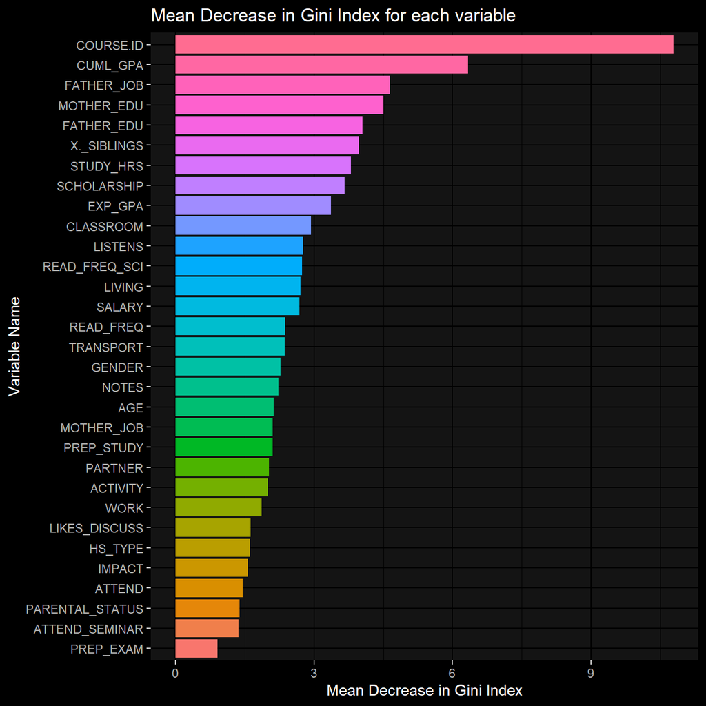

```r
model.randomForest <- randomForest(GRADE ~ ., data = data, subset = train, mty = 13,
                                  importance = TRUE)



imp <- model.randomForest$importance[, "MeanDecreaseGini"]
imp <- as.data.frame(imp)
imp$varnames <- rownames(imp)

ggplot(imp, aes(x=reorder(varnames, imp), weight=imp, fill=as.factor(imp))) +
  geom_bar() +
  ylab("Mean Decrease in Gini Index") +
  xlab("Variable Name") +
  coord_flip() +
  dark_theme_gray() +
  theme(legend.position="none") +
  labs(title = "Mean Decrease in Gini Index for each variable")
```

Looking at the chart above, - It is not surprising that course ID will affect the grade the most because some courses are definitely easier and others harder, so clearly everyone from the same course will have similar grades.

- Besides, cuml_gpa’s and exp_gpa’s effects are obvious too, as your past gpa is higher, your grade will be higher because if you performed well in the past, you will probably perform equally well in the future too.
- The impacts of MOTHER_EDU and FATHER_EDU seem to be significant as well. This is naturally true as I am expecting the higher the parents’ educations, the higher the students’ grades.
- The unexpected effect was from number of siblings which have more impact than study hours. I guess when you have more siblings means that you have to spend more time with siblings will result in worse grades? Time to verify this theory with a plot.

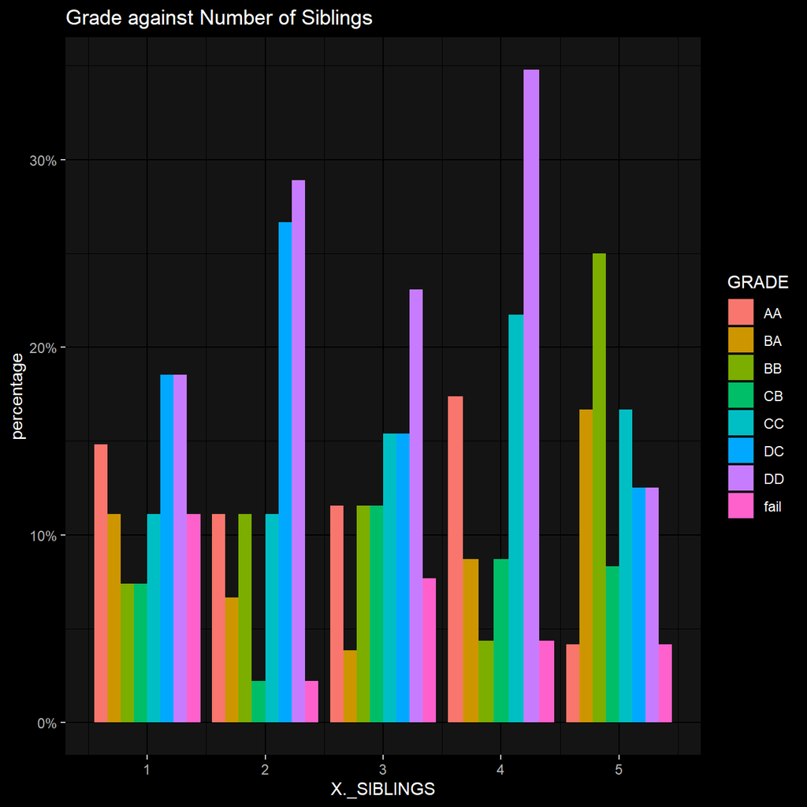

```r
data %>%
  group_by(X._SIBLINGS, GRADE) %>%
  summarize(n = n()) %>%
  mutate(percentage = n / sum(n)) %>%
  ggplot(data, mapping = aes(x = X._SIBLINGS, fill = GRADE, y = percentage)) +
  geom_bar(position = "dodge", stat = "identity") +
  dark_theme_gray() +
  labs(title = "Grade against Number of Siblings ") +
  scale_y_continuous(labels = function(x) paste0(x*100, "%"))
```

From this graph, I can’t exactly tell the relationship between Grade and X._Siblings. There does seem to have a particularly high number of DC and DD when the student has 2 siblings somehow. On the other hand, when you have 5 or more siblings, it seems unlikely to to get a grade AA due to distraction.

Meanwhile, relative to other numbers, having 4 siblings will make you more likely to get the best grade somehow. I don’t really get this relationship here.

### Testing the model

```r
pred.randomForest <- predict(model.randomForest, data[-train, ])
table(pred.randomForest, data$GRADE[-train])
```

```
##
## pred.randomForest AA BA BB CB CC DC DD fail
##              AA    2  2  0  1  0  0  0    0
##              BA    1  2  1  0  0  0  0    0
##              BB    0  0  0  0  0  0  0    0
##              CB    0  0  0  0  0  0  0    0
##              CC    0  0  1  0  3  0  0    0
##              DC    0  0  0  0  1  2  5    0
##              DD    0  0  5  0  1  5  4    1
##              fail  0  0  0  0  0  0  0    0
```

Hmmm, random forest’s prediction doesn’t seem to be particularly good here. It only yields an accuracy of 0.3513514. Slightly disappointed, let’s try with another model.

## Using Support Vector Machine

### Linear Kernel

```r
set.seed(1)
tune.svm.linear <- tune(svm, GRADE ~ . , data = data[train, ], kernel = "linear",
                        ranges = list(cost = c(0.1, 1, 10, 100, 1000), gamma = c(0.5, 1, 2, 3, 4)))
model.svm.linear <- svm(GRADE ~ . , data = data, kernel = "linear", cost =
                          tune.svm.linear$best.parameters$cost,
                        gamma = tune.svm.linear$best.parameters$gamma, subset = train)
pred.svm.linear <- predict(model.svm.linear, data[-train, ])
table(pred.svm.linear, data$GRADE[-train])
```

```
##
## pred.svm.linear AA BA BB CB CC DC DD fail
##            AA    2  1  0  0  0  1  1    0
##            BA    1  1  1  0  0  0  0    0
##            BB    0  0  0  0  0  0  0    0
##            CB    0  0  0  0  0  0  0    0
##            CC    0  0  1  0  2  0  0    0
##            DC    0  0  1  0  1  0  1    0
##            DD    0  2  4  1  2  6  7    1
##            fail  0  0  0  0  0  0  0    0
```

The accuracy of linear kernel for svm is 0.3243243.

### Polynomial Kernel

```r
tune.svm.poly <- tune(svm, GRADE ~ . , data = data[train, ], kernel = "polynomial",
                        ranges = list(cost = c(0.1, 1, 10, 100, 1000), gamma = c(0.5, 1, 2, 3, 4)))
model.svm.poly <- svm(GRADE ~ . , data = data, kernel = "polynomial", cost =
                          tune.svm.poly$best.parameters$cost,
                        gamma = tune.svm.poly$best.parameters$gamma, subset = train)
pred.svm.poly<- predict(model.svm.poly, data[-train, ])
table(pred.svm.poly, data$GRADE[-train])
```

```
##
## pred.svm.poly AA BA BB CB CC DC DD fail
##          AA    2  0  0  0  0  1  1    0
##          BA    1  2  2  0  0  0  0    0
##          BB    0  0  1  0  0  0  0    0
##          CB    0  1  1  0  0  0  1    0
##          CC    0  0  0  0  2  0  0    0
##          DC    0  0  1  0  1  1  4    0
##          DD    0  1  2  1  2  5  3    1
##          fail  0  0  0  0  0  0  0    0
```

The accuracy of polynomial kernel for svm is 0.2972973.

### Radial Kernel

Finally, let’s try with Radial Kernel

```r
tune.svm.radial <- tune(svm, GRADE ~ . , data = data[train, ], kernel = "radial",
                        ranges = list(cost = c(0.1, 1, 10, 100, 1000), gamma = c(0.5, 1, 2, 3, 4)))
model.svm.radial <- svm(GRADE ~ . , data = data,
                        kernel = "radial",cost =
                          tune.svm.radial$best.parameters$cost,
                        gamma = tune.svm.radial$best.parameters$gamma, subset = train)
pred.svm.radial <- predict(model.svm.radial, data[-train, ])
table(pred.svm.radial, data$GRADE[-train])
```

```
##
## pred.svm.radial AA BA BB CB CC DC DD fail
##            AA    0  0  0  0  0  0  0    0
##            BA    0  0  0  0  0  0  0    0
##            BB    0  0  0  0  0  0  0    0
##            CB    0  0  0  0  0  0  0    0
##            CC    0  0  0  0  0  0  0    0
##            DC    0  0  0  0  0  0  0    0
##            DD    3  4  7  1  5  7  9    1
##            fail  0  0  0  0  0  0  0    0
```

The accuracy of radial kernel for svm is 0.2432432.

Overall, the performance of the svm in this dataset seems to be quite poor, at least from the perspective of test set accuracy. The highest accuracy of all SVM models which is still lower than the accuracy from random forest model.

## Multinomial Logistic Regression

At this point I might as well test the logistic regression, although I am not particularly hopeful about it.

```r
model.log <- multinom(GRADE ~ . , data = data, subset = train)
pred.log <- predict(model.log, newdata = data[-train, ])
table(pred.log, data$GRADE[-train])
```

```
##
## pred.log AA BA BB CB CC DC DD fail
##     AA    1  0  0  0  1  0  1    0
##     BA    1  2  2  0  0  2  0    0
##     BB    1  1  1  0  0  1  1    0
##     CB    0  1  1  0  0  0  0    1
##     CC    0  0  1  0  1  0  1    0
##     DC    0  0  1  0  1  1  3    0
##     DD    0  0  1  1  1  3  3    0
##     fail  0  0  0  0  1  0  0    0
```

The accuracy of multinomial logistic regression is 0.2432432.

## The Lasso

Also will try out the Lasso, as not every column might affect the GRADE.

```r
x <- data[train, ] %>%
  select(-GRADE)
y <- data$GRADE[train]
data.tmp <- cbind(x, y)
grid <- 10^seq(10,-2, length =100)
model.tmp <- model.matrix(y ~ ., data = data.tmp)

model.lasso <- cv.glmnet(model.tmp, y, alpha = 1, family = "multinomial", lambda = grid)

model.tmp <- model.matrix(y ~ ., data = data.tmp[-train, ])

x <- data[-train, ] %>%
  select(-GRADE)
y <- data$GRADE[-train]
data.tmp <- cbind(x, y)
model.tmp <- model.matrix(y ~ ., data = data.tmp)

pred.lasso <- predict(model.lasso, newx = model.tmp, s = model.lasso$lambda.min,
                      type = "class")

table(pred.lasso, y)
```

```
##           y
## pred.lasso AA BA BB CB CC DC DD fail
##         AA  2  3  0  0  0  0  0    0
##         BA  0  1  0  0  0  0  0    0
##         DD  1  0  7  1  5  7  9    1
```

The accuracy of multinomial lasso regression is 0.3243243.

Not that bad. It was almost as good as random forest. Finally, let’s go with the KNN.

## K Nearest Neighbor

```r
x <- data %>%
  select(-GRADE)
y <- data$GRADE

train.control <- trainControl(method = "repeatedcv", number = 10)

model.knn <- train(GRADE ~., data = data[train, ], method = "knn",
               trControl = train.control,
                preProcess = c("center", "scale"),
                tuneLength = 10,
               tuneGrid   = expand.grid(k = 1:10))

pred.knn <- predict(model.knn, x[-train, ])
table(pred.knn, y[-train])
```

```
##
## pred.knn AA BA BB CB CC DC DD fail
##     AA    2  0  0  0  0  0  1    0
##     BA    1  1  0  0  0  0  0    0
##     BB    0  1  0  0  0  0  0    0
##     CB    0  0  0  0  0  1  0    0
##     CC    0  0  1  0  2  0  1    0
##     DC    0  0  0  0  1  2  1    0
##     DD    0  2  6  1  2  4  6    1
##     fail  0  0  0  0  0  0  0    0
```

```r
summary(model.knn)
```

```
##             Length Class      Mode
## learn        2     -none-     list
## k            1     -none-     numeric
## theDots      0     -none-     list
## xNames      82     -none-     character
## problemType  1     -none-     character
## tuneValue    1     data.frame list
## obsLevels    8     -none-     character
## param        0     -none-     list
```

The accuracy of knn is 0.3513514.

### Note on KNN

When I was carrying out KNN using the training above, I came into this warning (not just 1 or 2, but many of them)

```r
These variables have zero variances: LIVINGother, MOTHER_JOBself-employment
```

It totally struck me dumb because I have checked that there are multiple cases of exceptions regarding these columns.

After undertaking some research on my own ([source](https://rstatisticsblog.com/data-science-in-action/data-preprocessing/how-to-identify-variables-with-zero-variance/)), I found out that if the column contains too little of a class will result in unstable prediction model. Thus, I guess this explains why KNN’s best k is 1.

Regardless, KNN did perform relatively well.

## Conclusion

Despite many different types of classification algorithms are used, some of them aren’t even performing better than 30%, and the best ones are still below 40%.

I would say that a big factor was due to the size of dataset which after split into train test, there’s just slightly above 100 for the training set. In this scenario, I can’t do much as well to overcome this issue.

On the other hand, there could be much more reasons that explain the student’s grade like their lifestyle and other factors which may not be able to be measured easily.

Besides, I avoided PCA for dimentionality reduction because most of the columns are just factors instead of numerical, so I decide to just avoid them.

Finally, here’s a table of the prediction results

| model | result |
| --- | --- |
| Random Forest | 0.3513514 |
| Support Vector Machine - Linear | 0.3243243 |
| Support Vector Machine - Polynomial | 0.2972973 |
| Support Vector Machine - Radial | 0.2432432 |
| Multinomial Logistic Regression | 0.2432432 |
| The Lasso | 0.3243243 |
| KNN | 0.3513514 |

Out of all, random forest and KNN performed equally well at an accuracy of 35%. I didn’t do any further optimization except for using some cross validations to optimize the parameters.

Nevertheless, I am rather satisfied with this 35% accuracy for it is a multiclass classification.